# Análisis exploratorio de datos

Métodos de análisis no paramétricos

Dr. José A. Gallardo.

Profesor adjunto de la Pontificia Universidad Católica de Valparaíso  
jose.gallardo@pucv.cl

April 04, 2021

#### Objetivos de aprendizaje

Realizar un análisis exploratorio de datos con el **[software R](https://es.r4ds.hadley.nz/an%C3%A1lisis-exploratorio-de-datos-eda.html)**.

#### Conceptos importantes

**Variable cualitativa:** Variables que expresan cualidades o atributos de los individuos o el ambiente.

**Variable cuantitativa:** Variables que adoptan valores numéricos

**Variable nominal:**Variables que no tienen orden o jerarquía dentro de sus elementos.

**Variable ordinal:**Variables cuyos elementos se pueden ordenar en una jerarquía.

**Variable binaria:** Variables con dos estados o niveles.

#### Software.

Esta es la versión de R que se usó para crear esta guía.

```r
R.version.string
```

```
## [1] "R version 3.6.1 (2019-07-05)"
```

#### Librerías.

**{psych}** , **{readxl}**

#### Comandos y argumentos para observar el comportamiento de una variable.

1.- Resumen estadístico  
*summary()*

2.- Estructura de un objeto  
**str()**

3.- Tabla de distribución de frecuencia  
**table()**

4.- Gráfica x-y de puntos“p”, lineas “l” o ambas “b”.  
**plot()**

5.- Gráfica de cajas y bigotes.  
**boxplot()**

6.- Mediante una función de densidad empírica.  
**density()**

7.- Coeficiente de correlación.  
**cor()**

#### EJERCICIOS

Los ejercicios de esta guía se realizarán con un extracto del set de datos **GSI_DATASET.xlsx**. Este set de datos pertenece a un estudio de investigación que compara diferentes variables cualitativas y cuantitativas entre salmones diploides y triploides. Contiene 7 columnas denominadas: Fish_ID, Sex, Ploidy, Length_mm, Weight_g, Gonad_weight_g y GSI (Indice gonado somático).

Realice los ejercicios de forma colaborativa con uno o dos compañeros.

**Ejercicio 1.** Elabore un archivo Rmarkdown o file con extensión **.Rmd** en Rstudio o Rstudio.cloud y configurelo para exportar el resultado como un documento dinámico **pdf**.

En el primier bloque de códigos o **chunk** configure los comandos de la siguiente manera *knitr::opts_chunk$set(echo = TRUE)* y cargue las librerías **psych**, **readxl**, **stats** y **graphics** usando la función library().

```r
knitr::opts_chunk$set(echo = TRUE)
library(psych)
```

```r
library(readxl)
library(stats)
library(graphics)
```

**Ejercicio 2.** Borre los bloques de códigos R que se generan automáticamente con cada archivo .Rmd y reemplacelos por 5 nuevos bloques de códigos con el botón verde **+C** que se encuentra en la parte superior del panel de códigos. Ejecute cada uno de los siguientes ejercicios en un bloque de códigos diferente.

**Ejercicio 3.** Importe el set de datos **GSI_DATASET** usando la función *read_excel()* de la librería *readxl*. Explore el set de datos usando las funciones *summary()* y *str()*.

```r
GSI <- read_excel("GSI_DATASET.xlsx")
summary(GSI)
```

```
##    Fish_ID              Sex               Ploidy            Length_mm
##  Length:30          Length:30          Length:30          Min.   :369.0
##  Class :character   Class :character   Class :character   1st Qu.:400.2
##  Mode  :character   Mode  :character   Mode  :character   Median :436.0
##                                                           Mean   :440.0
##                                                           3rd Qu.:460.8
##                                                           Max.   :595.0
##     Weight_g      Gonad_weight_g         GSI
##  Min.   : 402.0   Length:30          Length:30
##  1st Qu.: 587.5   Class :character   Class :character
##  Median : 940.0   Mode  :character   Mode  :character
##  Mean   : 914.4
##  3rd Qu.:1139.8
##  Max.   :1694.0
```

```r
str(GSI)
```

```
## tibble [30 × 7] (S3: tbl_df/tbl/data.frame)
##  $ Fish_ID       : chr [1:30] "AD1" "AD2" "AD3" "AD4" ...
##  $ Sex           : chr [1:30] "Female" "Female" "Male" "Male" ...
##  $ Ploidy        : chr [1:30] "Diploid" "Diploid" "Diploid" "Diploid" ...
##  $ Length_mm     : num [1:30] 500 431 445 448 439 519 477 389 595 396 ...
##  $ Weight_g      : num [1:30] 1407 932 1169 1089 960 ...
##  $ Gonad_weight_g: chr [1:30] "4.03" "2.3" "0.67" "0.8" ...
##  $ GSI           : chr [1:30] "0.286425018" "0.246781116" "0.057313944" "0.073461892" ...
```

**Ejercicio 4.** Note que del ejercicio anterior algunas variables fueron erradamente codificadas como caracter o texto en ves de factor o numero. Antes de continuar con el EDA use la función **as.factor()** para correguir este error en la importación en las variables Fish_ID, Sex, Ploidy y la función **as.numeric()** para correguir este error en la importación en las variables Gonad_weight_g y GSI. Siga el siguiente ejemplo:

```r
# GSI$Fish_ID <- as.factor(GSI$Fish_ID)
```

```r
GSI$Fish_ID <- as.factor(GSI$Fish_ID)
GSI$Sex <- as.factor(GSI$Sex)
GSI$Ploidy <- as.factor(GSI$Ploidy)
GSI$Gonad_weight_g <- as.numeric(GSI$Gonad_weight_g)
GSI$GSI <- as.numeric(GSI$GSI)
```

Vuelva a ejecutar los comandos summary() y str() para comprobar que las variables están adecuadamente codificadas.

```r
summary(GSI)
```

```
##     Fish_ID       Sex          Ploidy     Length_mm        Weight_g
##  AD1    : 1   Female:17   Diploid :15   Min.   :369.0   Min.   : 402.0
##  AD10   : 1   Male  :13   Triploid:15   1st Qu.:400.2   1st Qu.: 587.5
##  AD11   : 1                             Median :436.0   Median : 940.0
##  AD12   : 1                             Mean   :440.0   Mean   : 914.4
##  AD13   : 1                             3rd Qu.:460.8   3rd Qu.:1139.8
##  AD14   : 1                             Max.   :595.0   Max.   :1694.0
##  (Other):24
##  Gonad_weight_g        GSI
##  Min.   :0.1200   Min.   :0.02713
##  1st Qu.:0.5075   1st Qu.:0.05009
##  Median :0.7350   Median :0.06798
##  Mean   :1.1247   Mean   :0.12108
##  3rd Qu.:1.9575   3rd Qu.:0.20763
##  Max.   :4.0300   Max.   :0.40267
##
```

```r
str(GSI)
```

```
## tibble [30 × 7] (S3: tbl_df/tbl/data.frame)
##  $ Fish_ID       : Factor w/ 30 levels "AD1","AD10","AD11",..: 1 8 9 10 11 12 13 14 15 2 ...
##  $ Sex           : Factor w/ 2 levels "Female","Male": 1 1 2 2 2 2 1 1 2 1 ...
##  $ Ploidy        : Factor w/ 2 levels "Diploid","Triploid": 1 1 1 1 1 1 1 1 1 1 ...
##  $ Length_mm     : num [1:30] 500 431 445 448 439 519 477 389 595 396 ...
##  $ Weight_g      : num [1:30] 1407 932 1169 1089 960 ...
##  $ Gonad_weight_g: num [1:30] 4.03 2.3 0.67 0.8 0.53 0.83 2.81 1.59 0.84 2.11 ...
##  $ GSI           : num [1:30] 0.2864 0.2468 0.0573 0.0735 0.0552 ...
```

**Ejercicio 5.** A partir del set de datos GSI_DATASET elabore un histograma, una función de densidad y un boxplot de las variables cuantitativas continuas: *Weight_g*,*Length_mm*. Use las funciones hist(), plot(density() y boxplot().

**Luego responda las siguientes preguntas** ¿Tienen estas variables una distribución normal? ¿Por qué si, por qué no? ¿En cual observa valores atípicos? ¿Calcule la moda y la mediana de cada variable usando programación R?

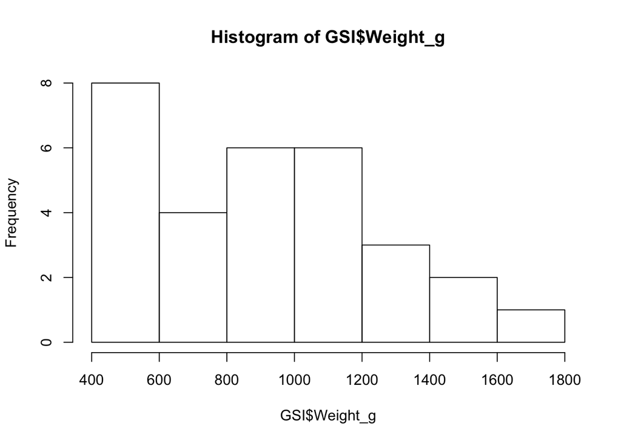

```r
hist(GSI$Weight_g)
```

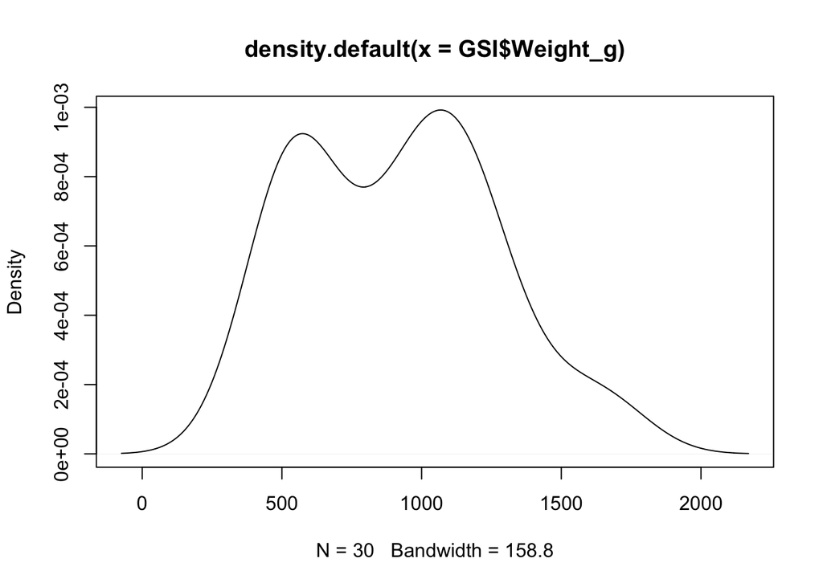

```r
plot(density(GSI$Weight_g))
```

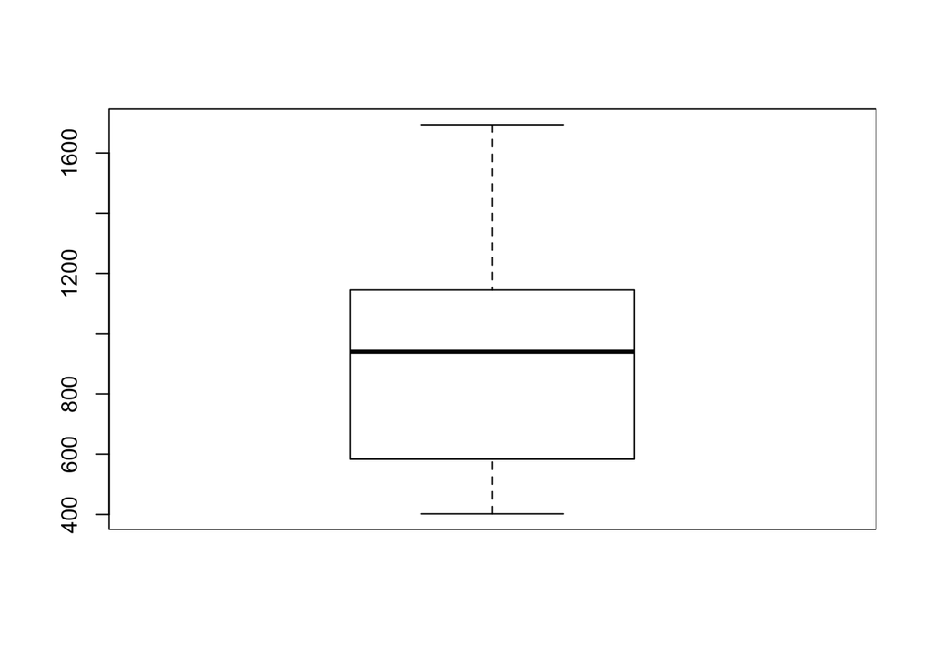

```r
boxplot(GSI$Weight_g)
```

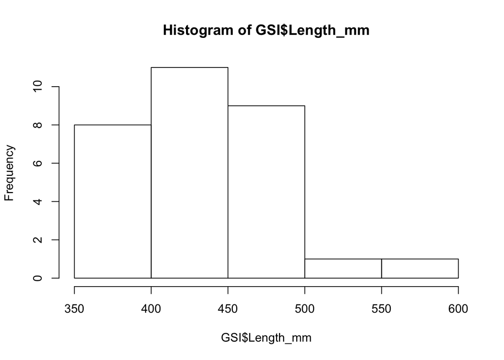

```r
hist(GSI$Length_mm)
```

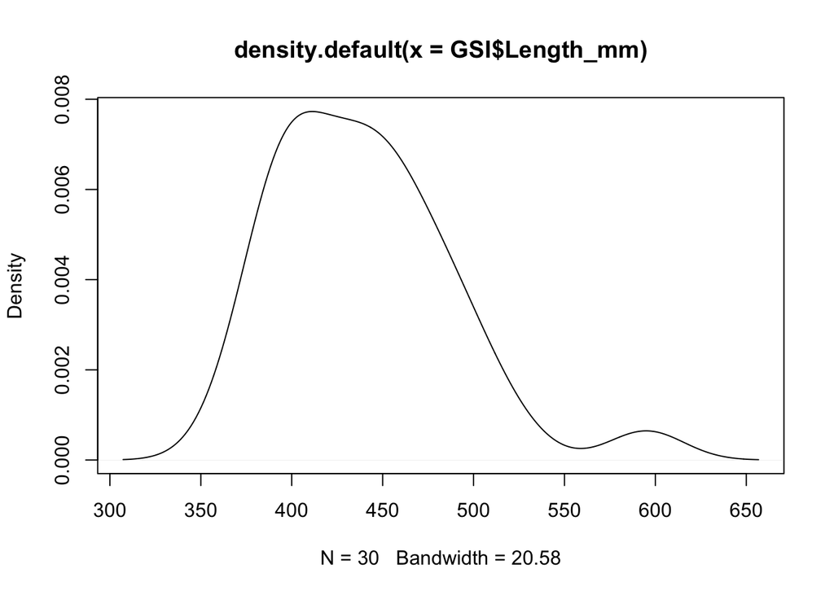

```r
plot(density(GSI$Length_mm))
```

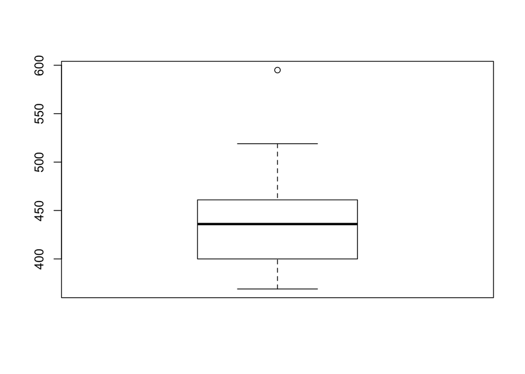

```r
boxplot(GSI$Length_mm)
```

**Ejercicio 6.** Investigue si existe covariación (correlación) entre las variables: *Weight_g* v/s *Length_mm*. Use las funciones plot() y cor().

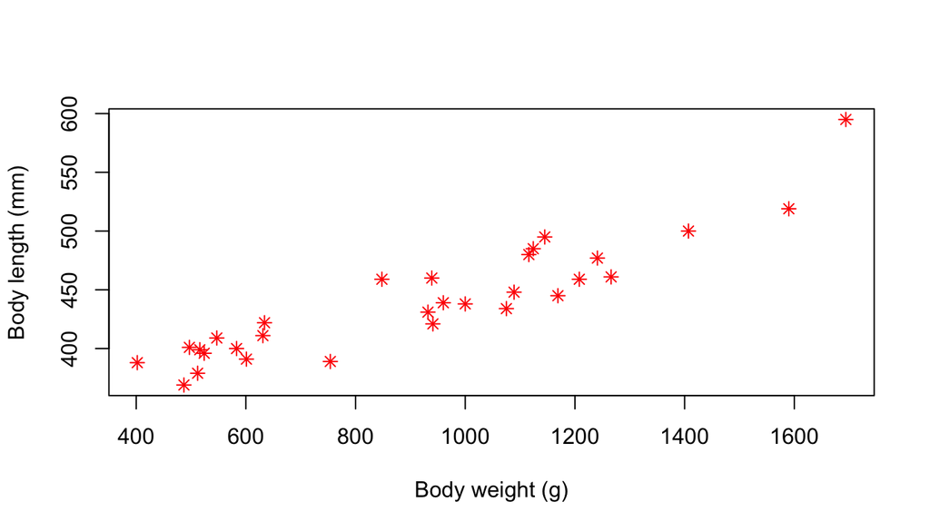

Correlacion entre Body weight y Body length

```r
plot(x=GSI$Weight_g , y=GSI$Length_mm , col="red", pch=8,  xlab = "Body weight (g)", ylab = "Body length (mm)")
```

```r
cor(x=GSI$Weight_g, y=GSI$Length_mm)
```

```
## [1] 0.9147454
```

**Ejercicio 7.** Investigue si existe covariación (correlación) entre las variables: *Weight_g* v/s *GSI*. Use las funciones plot() y cor().

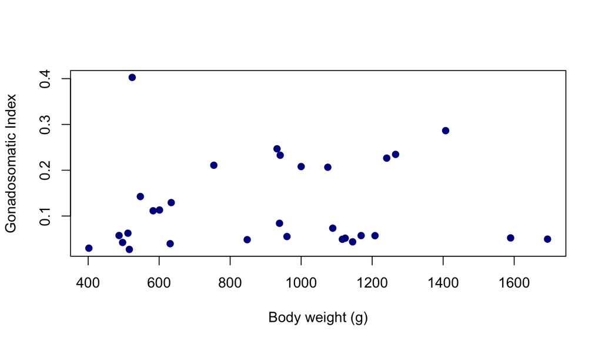

Correlación entre Body weight e Índice gonadosomatico (GSI)

```r
plot(x=GSI$Weight_g, y=GSI$GSI, col="blue4", pch=19,  xlab = "Body weight (g)", ylab = "Gonadosomatic Index")
```

```r
cor(x=GSI$Weight_g, y=GSI$GSI)
```

```
## [1] 0.05421254
```

**Ejercicio 8.** Investigue si existe covariación (correlación) todas las variables cuantitativas. Use la función pairs.panels(), seleccione solo las columnas 4:7 con el siguiente argumento *[,4:7]*.

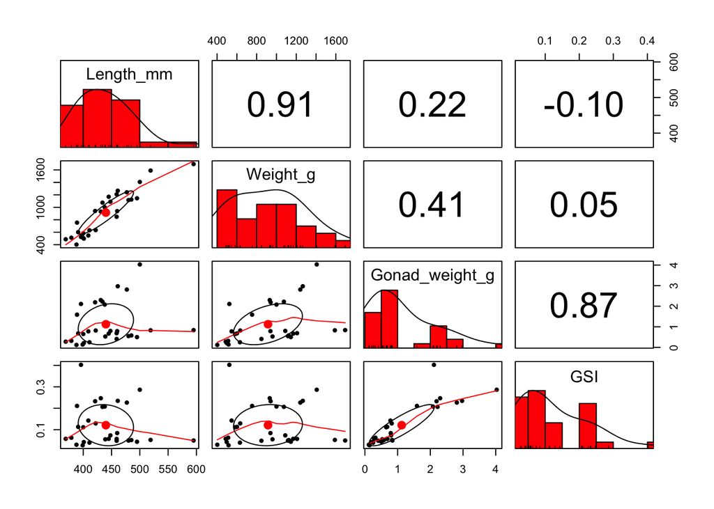

```r
# Gráfica de correlación de variables continuas
pairs.panels(GSI[,4:7], method = "pearson", hist.col = "red",  density = TRUE)
```

**Ejercicio 9.** Investigue si existe covariación de la variable *Weight_g* en función de la *Ploidy*. Use la función boxplot().

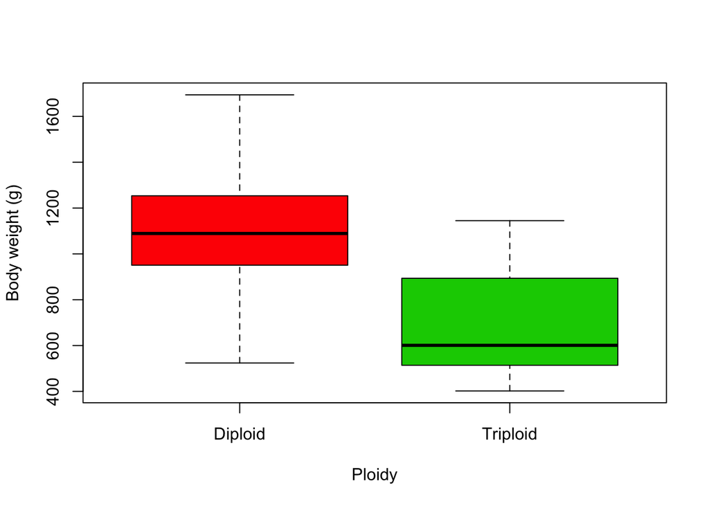

Variación del peso del cuerpo en función de la ploidía

```r
boxplot(GSI$Weight_g ~ GSI$Ploidy, col=c(2,3), xlab = "Ploidy", ylab = "Body weight (g)")
```

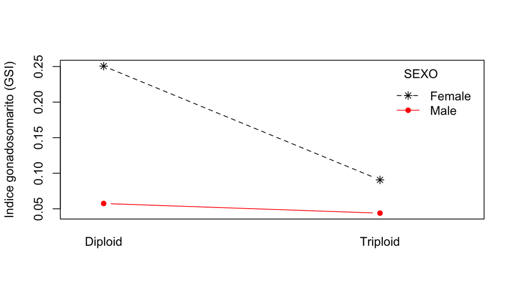

Efecto de la interacción entre Ploidia y sexo sobre el IGS.

```r
interaction.plot(GSI$Ploidy, GSI$Sex, GSI$GSI, ylab = "Indice gonadosomarito (GSI)", col = c(1,2), pch = c(8, 16), type = "b", trace.label = "SEXO", xlab = "")
```

**Ejercicio 9.** Investigue cual de las dos variables ploidia (*Ploidy*) y sexo (*Sex*) tiene una mayor influencia sobre la variable peso del cuerpo (*Weight_g*) Use la función plot.design.

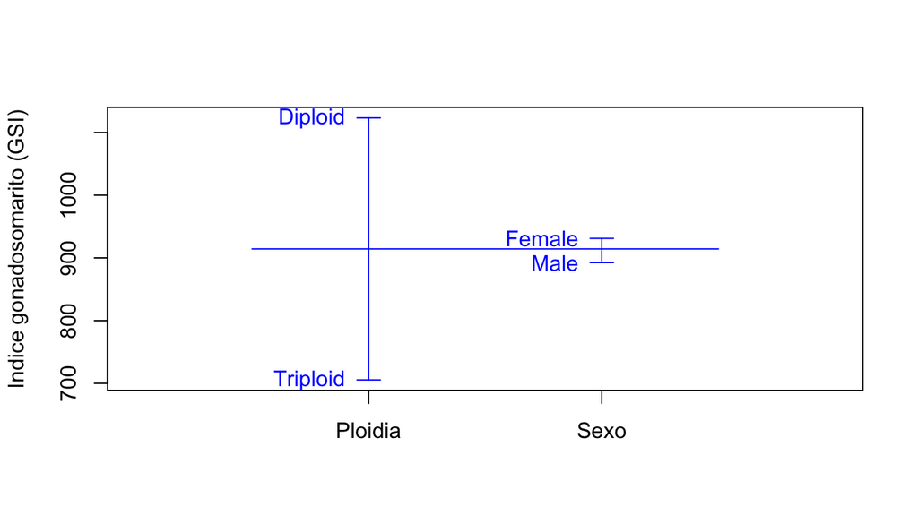

```r
plot.design(GSI$Weight_g ~ GSI$Ploidy * GSI$Sex, mean, ylab = "Indice gonadosomarito (GSI)", col = c(4), xlab="", xaxt="n")
axis(1, 1:2, c("Ploidia", "Sexo"))
```